# Figures for the ggdist paper

Matthew Kay

2023-03-11

## Introduction

This document generates the various figures for the paper, *ggdist: Visualizations of Distributions and Uncertainty in the Grammar of Graphics*.

## Setup

These libraries are needed to build this file:

```r
library(ggplot2)
library(ggdist)              # obviously
library(distributional)      # for dist_...
library(dplyr)               # for data manipulation
library(sysfonts)            # for using custom fonts
library(brms)                # for brm() (model-fitting)
library(posterior)           # rvar
library(patchwork)
library(ggtext)              # element_textbox_simple
library(ragg)                # agg_png
library(colorspace)
library(broom)               # augment
library(tidyr)
library(palmerpenguins)
```

And this ggplot theme, based on `theme_ggdist()`, using the Source Sans Pro font (in the `fonts/` folder):

```r
knitr::opts_chunk$set(dev = "ragg_png", fig.ext = "png")

font_add(
  family = "Source Sans Pro",
  regular = "fonts/source-sans/SourceSansPro-Regular.ttf",
  bold = "fonts/source-sans/SourceSansPro-Bold.ttf",
  italic = "fonts/source-sans/SourceSansPro-Italic.ttf",
  bolditalic = "fonts/source-sans/SourceSansPro-BoldItalic.ttf",
)

theme_set(
  theme_light(base_family = "Source Sans Pro") + theme(
    axis.line.x = element_line(color = "gray70", linewidth = rel(0.5)),
    axis.line.y = element_line(color = "gray70", linewidth = rel(0.5)),
    axis.title.x = element_text(margin = margin(t = 7)),
    axis.title.y = element_text(margin = margin(r = 7)),
    panel.grid.major = element_blank(),
    panel.grid.minor = element_blank(),
    panel.border = element_blank(),
    strip.text = element_text(color = "black", margin = margin(6, 6, 6, 6)),
    strip.background = element_rect(fill = "gray90")
  )
)
```

And some functions we’ll use for annotating stuff:

```r
red_ = "#e41a1c"
blue_ = "#6BAED6"
label_color = red_

bracket_ = function(..., x, xend = x, y, yend = y, color = label_color, linewidth = 0.5) {
  annotate("segment",
    arrow = arrow(angle = 90, ends = "both", length = unit(3, "points")),
    color = color, linewidth = linewidth,
    x = x, xend = xend, y = y, yend = yend,
    ...
  )
}
arrow_ = function(..., curvature = 0, x, xend = x, y, yend = y, color = label_color, linewidth = 0.5) {
  annotate("curve",
    color = color, arrow = arrow(angle = 45, length = unit(3, "points"), type = "closed"),
    curvature = curvature, linewidth = linewidth,
    lineend = "square", linejoin = "mitre",
    x = x, xend = xend, y = y, yend = yend
  )
}
label_ = function(..., hjust = 0, color = label_color, family = "serif") {
  annotate("text",
    color = color, hjust = hjust, lineheight = 1,
    size = 3.75,
    family = family,
    ...
  )
}
```

## Teaser

This section creates the subfigures used to create the teaser figure.

### Slabinterval

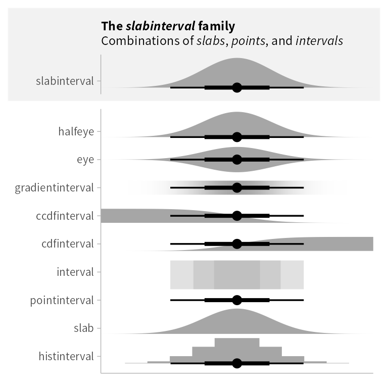

### Wee people

Based on my [wee people example](https://github.com/mjskay/uncertainty-examples/blob/master/weepeople_dotplots.md).

We need to register the Wee People font:

```r
font_add(
  family = "weepeople",
  regular = "fonts/wee-people/weepeople.ttf"
)
```

Then set up a dataset of people:

```r
set.seed(1234)

people_df = data.frame(
  x = qnorm(ppoints(100), 1:2),
  set = c("a", "b"),
  icon = factor(sample(52, 100, replace = TRUE))
)

# the lower and upper case letters in the Wee People font are people:
people_letters = c(letters, LETTERS)
```

Then a plot:

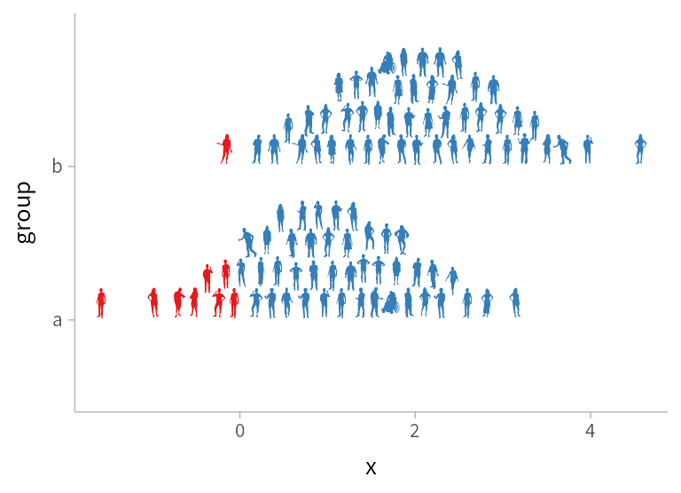

```r
p = people_df |>
  ggplot(aes(x = x, y = set, group = set, shape = icon, color = x > 0)) +
  geom_dots(family = "weepeople", dotsize = 2.4, layout = "swarm")+
  scale_shape_manual(values = people_letters, guide = "none") +
  scale_color_brewer(palette = "Set1", guide = "none") +
  ylab("group")

p
```

```r
ggsave("figs/teaser-weepeople.pdf", plot = p, device = cairo_pdf, width = 4.0, height = 2.9)
```

### Rainclouds

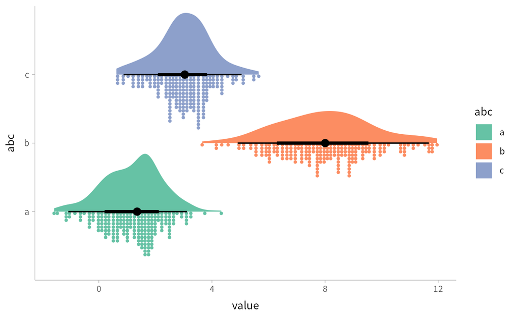

```r
set.seed(12345) # for reproducibility

p = data.frame(
  abc = c("a", "b", "c"),
  value = rnorm(600, c(1, 8, 3), c(1, 1.7, 1))
) %>%
  ggplot(aes(y = abc, x = value, fill = abc)) +
  stat_slab(density = "unbounded") +
  stat_dotsinterval(side = "bottom", slab_linewidth = NA, slab_color = NA, layout = "bin") +
  scale_fill_brewer(palette = "Set2")

p
```

```r
ggsave("figs/teaser-raincloud.pdf", device = cairo_pdf)
```

### Fit lines

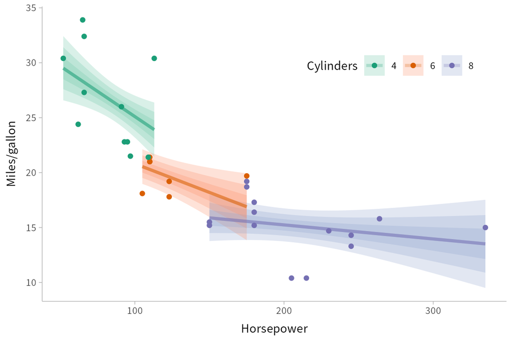

```r
m_mpg = lm(mpg ~ hp * cyl, data = mtcars)
p = mtcars %>%
  group_by(cyl) %>%
  expand(hp = seq(min(hp), max(hp), length.out = 101)) %>%
  augment(m_mpg, newdata = ., se_fit = TRUE) %>%
  ggplot(aes(x = hp, fill = ordered(cyl), color = ordered(cyl))) +
  stat_lineribbon(
    aes(dist = "norm", arg1 = .fitted, arg2 = .se.fit),
    alpha = 1/4
  ) +
  geom_point(aes(y = mpg), data = mtcars) +

  scale_fill_brewer(palette = "Set2") +
  scale_color_brewer(palette = "Dark2") +
  labs(
    color = "Cylinders",
    fill = "Cylinders",
    y = "Miles/gallon",
    x = "Horsepower"
  ) +
  theme(legend.position = c(0.75, 0.8), legend.direction = "horizontal")

p
```

```r
ggsave("figs/teaser-mtcars-lines.pdf", device = cairo_pdf)
```

### Logit dotplots

Fit model:

```r
gentoo = penguins %>%
  filter(species == "Gentoo", !is.na(sex))

m = glm(sex == "male" ~ body_mass_g, data = gentoo, family = binomial)
m
```

```
##
## Call:  glm(formula = sex == "male" ~ body_mass_g, family = binomial,
##     data = gentoo)
##
## Coefficients:
## (Intercept)  body_mass_g
##   -55.03337      0.01089
##
## Degrees of Freedom: 118 Total (i.e. Null);  117 Residual
## Null Deviance:       164.9
## Residual Deviance: 45.1  AIC: 49.1
```

Logit dotplots:

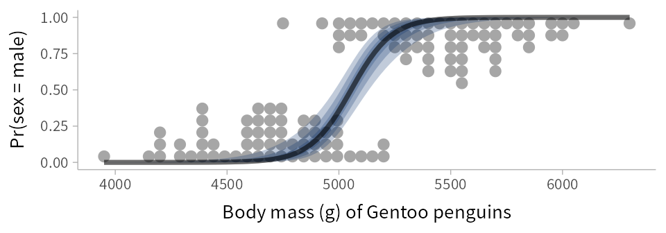

```r
# construct a prediction grid for the fit line
prediction_grid = with(gentoo,
  data.frame(body_mass_g = seq(min(body_mass_g), max(body_mass_g), length.out = 100))
)

p = prediction_grid %>%
  bind_cols(predict(m, ., se.fit = TRUE)) %>%
  mutate(
    # distribution describing uncertainty in log odds
    log_odds = dist_normal(fit, se.fit),
    # inverse-logit transform the log odds to get
    # distribution describing uncertainty in Pr(sex == "male")
    p_male = dist_transformed(log_odds, plogis, qlogis)
  ) %>%
  ggplot(aes(x = body_mass_g)) +
  geom_dots(
    aes(y = as.numeric(sex == "male"), side = sex),
    scale = 0.5,
    data = gentoo
  ) +
  stat_lineribbon(
    aes(ydist = p_male), alpha = 1/4, fill = "#08306b"
  ) +
  scale_side_mirrored(guide = "none") +
  coord_cartesian(ylim = c(0, 1)) +
  labs(
    x = "Body mass (g) of Gentoo penguins",
    y = "Pr(sex = male)"
  )

p
```

```r
ggsave("figs/teaser-logit_dotplots.pdf", device = cairo_pdf)
```

## Setting the stage

### A simplified notation for the grammar of graphics

We’re going to use a slightly modified version of the mtcars dataset:

```r
cars = mtcars |>
  mutate(weight = wt)
```

We can generate a nice scatterplot of it:

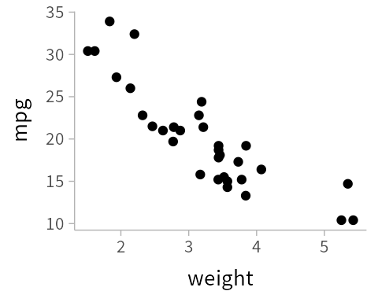

```r
p = cars |>
  ggplot(aes(x = weight, y = mpg)) +
  geom_point()
p
```

```r
ggsave("figs/2-mpg_v_weight.pdf", device = cairo_pdf)
```

### Uncertainty as she is spoke

The (mean, sd) approach:

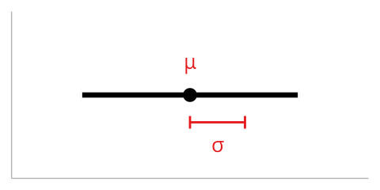

```r
p = data.frame(a = dist_normal(0, 1)) |>
  ggplot(aes(xdist = a)) +
  stat_pointinterval(.width = .95) +
  scale_y_continuous(breaks = NULL) +
  scale_x_continuous(breaks = NULL, limits = c(-2.95, 2.95)) +
  label_(label = "italic(mu)", x = 0, y = 0.19, hjust = 0.5, parse = TRUE) +
  bracket_(x = 0, xend = 1, y = -0.18) +
  label_(label = "italic(sigma)", x = 0.5, y = -0.34, hjust = 0.5, parse = TRUE) +
  labs(y = NULL, x = NULL)

p
```

```r
ggsave("figs/2-mean_sd_interval.pdf", device = cairo_pdf)
```

The magic numbers approach:

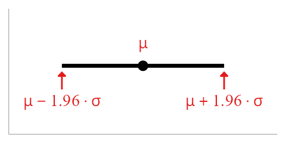

```r
p = data.frame(a = dist_normal(0, 1)) |>
  ggplot(aes(xdist = a)) +
  stat_pointinterval(.width = .95, justification = 0.55) +
  scale_y_continuous(breaks = NULL) +
  scale_x_continuous(breaks = NULL, limits = c(-2.95, 2.95)) +
  label_(label = "italic(mu)", x = 0, y = 0.17, hjust = 0.5, parse = TRUE) +
  arrow_(x = -1.96, y = -0.2, yend = -0.06) +
  label_(label = "italic(mu - 1.96%.%sigma)", x = -1.96, y = -0.32, hjust = 0.5, parse = TRUE) +
  arrow_(x = 1.96, y = -0.2, yend = -0.06) +
  label_(label = "italic(mu + 1.96%.%sigma)", x = 1.96, y = -0.32, hjust = 0.5, parse = TRUE) +
  labs(y = NULL, x= NULL)
p
```

```r
ggsave("figs/2-xmin_xmax_interval.pdf", device = cairo_pdf)
```

## Distributional vis

### Intervals

Interval with manually-calculated quantile interval:

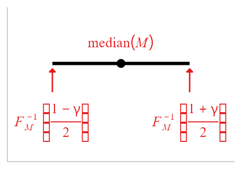

```r
p = data.frame(a = dist_normal(0, 1)) |>
  ggplot(aes(xdist = a)) +
  stat_pointinterval(.width = .95, justification = 0.65) +
  scale_y_continuous(breaks = NULL) +
  scale_x_continuous(breaks = NULL, limits = c(-2.95, 2.95)) +
  label_(label = "median(italic(M))", x = 0, y = 0.15, hjust = 0.5, parse = TRUE) +
  arrow_(x = -1.96, y = -0.2, yend = -0.04) +
  label_(label = "{italic(F)[italic(M)]^{-1}}~bgroup('[', over(1 - gamma, 2), ']')", x = -1.96, y = -0.42, hjust = 0.5, parse = TRUE) +
  arrow_(x = 1.96, y = -0.2, yend = -0.04) +
  label_(label = "{italic(F)[italic(M)]^{-1}}~bgroup('[', over(1 + gamma, 2), ']')", x = 1.96, y = -0.42, hjust = 0.5, parse = TRUE) +
  labs(y = NULL, x = NULL)
p
```

```r
ggsave("figs/3-geom_pointinterval_quantiles.pdf", device = cairo_pdf)
```

Two intervals using mass mapped onto linewidth (still manually calculated):

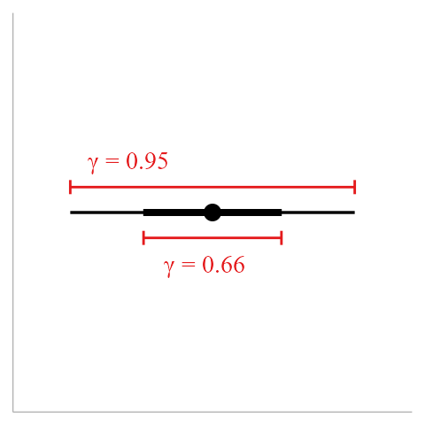

```r
p = data.frame(a = dist_normal(0, 1)) |>
  ggplot(aes(xdist = a)) +
  stat_pointinterval() +
  scale_y_continuous(breaks = NULL) +
  scale_x_continuous(breaks = NULL, limits = c(-2.5, 2.5)) +
  bracket_(x = -1.96, xend = 1.96, y = 0.07) +
  label_(label = "γ = 0.95", x = -1.72, y = 0.12, hjust = 0, vjust = 0) +
  bracket_(x = -0.95, xend = 0.95, y = -0.07) +
  label_(label = "γ = 0.66", x = -0.67, y = -0.12, hjust = 0, vjust = 1) +
  labs(y = NULL, x = NULL)

p
```

```r
ggsave("figs/3-stat_pointinterval_linewidth.pdf", device = cairo_pdf)
```

Three intervals using mass mapped onto color:

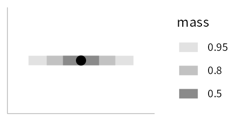

```r
p = data.frame(a = dist_normal(0, 1)) |>
  ggplot(aes(xdist = a)) +
  stat_pointinterval(aes(interval_color = after_stat(level)), linewidth = 18, .width = c(.5, .8, .95)) +
  scale_y_continuous(breaks = NULL) +
  scale_x_continuous(breaks = NULL, limits = c(-2.5, 2.5)) +
  scale_color_discrete_sequential(palette = "Light Grays", aesthetics = "interval_color", nmax = 4) +
  labs(y = NULL, x = NULL, interval_color = "mass")

p
```

```r
ggsave("figs/3-stat_pointinterval_color.pdf", device = cairo_pdf)
```

Two intervals on distribution $M$:

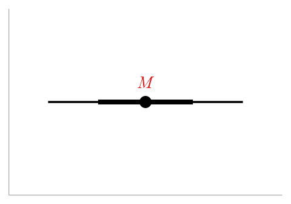

```r
p = data.frame(a = dist_normal(0, 1)) |>
  ggplot(aes(xdist = a)) +
  stat_pointinterval() +
  scale_y_continuous(breaks = NULL) +
  scale_x_continuous(breaks = NULL, limits = c(-2.5, 2.5)) +
  label_(label = "italic(M)", x = 0, y = 0.15, hjust = 0.5, vjust = 1, parse = TRUE) +
  labs(y = NULL, x = NULL)

p
```

```r
ggsave("figs/3-stat_pointinterval_A.pdf", device = cairo_pdf)
```

Two intervals on distribution $\textrm{Normal}(\mu, \sigma)$:

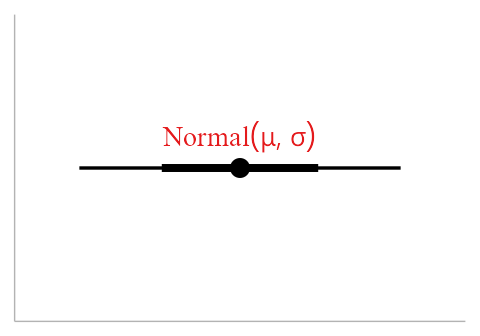

```r
p = data.frame(a = dist_normal(0, 1)) |>
  ggplot(aes(xdist = a)) +
  stat_pointinterval() +
  scale_y_continuous(breaks = NULL) +
  scale_x_continuous(breaks = NULL, limits = c(-2.5, 2.5)) +
  label_(label = "Normal(italic(mu), italic(sigma))", x = 0, y = 0.17, hjust = 0.5, vjust = 1, parse = TRUE) +
  labs(y = NULL, x = NULL)

p
```

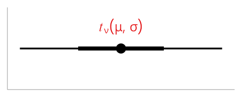

```r
ggsave("figs/3-stat_pointinterval_normal.pdf", device = cairo_pdf)
p = data.frame(a = dist_student_t(6, 0, 1)) |>
  ggplot(aes(xdist = a)) +
  stat_pointinterval() +
  scale_y_continuous(breaks = NULL) +
  scale_x_continuous(breaks = NULL, limits = c(-2.5, 2.5)) +
  label_(label = "italic(t[nu])(italic(mu), italic(sigma))", x = 0, y = 0.4, hjust = 0.5, vjust = 1, parse = TRUE) +
  labs(y = NULL, x = NULL)

p
```

```r
ggsave("figs/3-stat_pointinterval_student_t.pdf", device = cairo_pdf)
```

### Ribbons

Build the model:

```r
m_mpg = brm(
  mpg ~ weight,
  family = lognormal,
  data = cars,
  iter = 5000,
  cores = 4,
  file = "models/m_mpg.rds",
  seed = 3142013
)
```

And generate the predictions:

```r
set.seed(9304929)
preds = data.frame(weight = seq(min(cars$weight), max(cars$weight), length.out = 100))
preds = preds |>
  mutate(mpg_given_weight = rvar(posterior_predict(m_mpg, preds)))
head(preds)
```

```
##     weight mpg_given_weight
## 1 1.513000         31 ± 4.8
## 2 1.552505         31 ± 4.7
## 3 1.592010         30 ± 4.6
## 4 1.631515         30 ± 4.6
## 5 1.671020         30 ± 4.6
## 6 1.710525         29 ± 4.4
```

Now the vis:

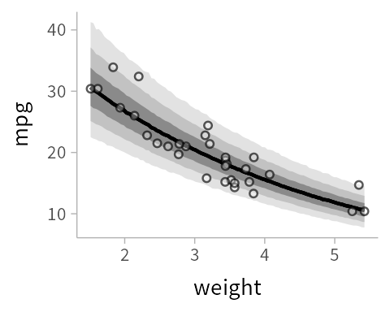

```r
p = preds |>
  ggplot(aes(x = weight)) +
  stat_lineribbon(aes(ydist = mpg_given_weight), linewidth = 0.75) +
  geom_point(aes(y = mpg), data = cars, color = alpha("black", 0.65), stroke = 0.65, shape = 21, fill = alpha("white", 0.35), size = 1.25) +
  scale_fill_discrete_sequential(palette = "Light Grays", nmax = 4) +
  guides(fill = "none")

p
```

```r
ggsave("figs/3-lineribbon.pdf", device = cairo_pdf)
```

lineribbon fan:

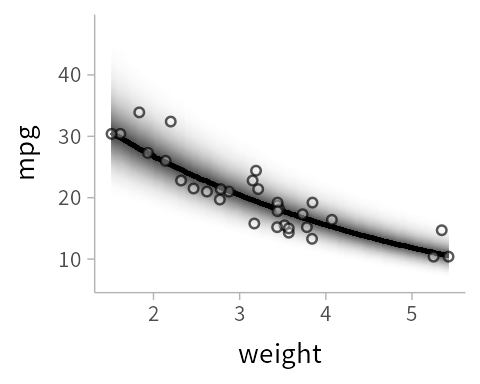

```r
p = preds |>
  ggplot(aes(x = weight)) +
  stat_lineribbon(aes(ydist = mpg_given_weight, fill = after_stat(.width)), linewidth = 0.75, .width = ppoints(100)) +
  geom_point(aes(y = mpg), data = cars, color = alpha("black", 0.65), stroke = 0.65, shape = 21, fill = alpha("white", 0.35), size = 1.25) +
  scale_fill_gradient(low = "gray25", high = "white") +
  guides(fill = "none")

p
```

```r
ggsave("figs/3-lineribbon_fan.pdf", device = cairo_pdf)
```

### Slabs

Two density plots:

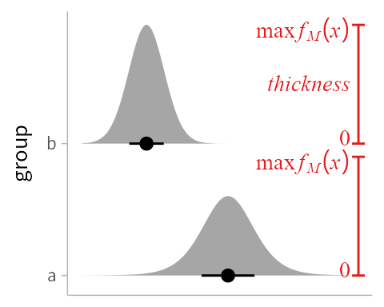

```r
two_a = data.frame(
  nu = c(8, 60),
  mu = c(6, 1),
  sigma = c(1.6, 1.1),
  group = factor(c("a", "b"))
)

p = two_a |>
  ggplot(aes(xdist = dist_student_t(nu, mu, sigma), y = group)) +
  stat_slab() +
  stat_pointinterval(.width = 0.66, linewidth = 0.5, side = "top") +
  bracket_(x = 14, y = 2, yend = 2.9) +
  bracket_(x = 14, y = 1, yend = 1.9) +
  label_(x = 13.5, y = 2.5, label = "thickness", fontface = "italic", hjust = 1, vjust = 0.9) +
  label_(x = 13.5, y = c(1.01, 2.01), label = "0", hjust = 1, vjust = 0.2) +
  label_(x = 13.5, y = c(1.92, 2.92), label = "max(italic(f[M](x)))", parse = TRUE, hjust = 1, vjust = 0.8) +
  scale_x_continuous(breaks = NULL, limits = c(-3, 14)) +
  scale_y_discrete(expand = expansion(0.15)) +
  labs(x = NULL)

p
```

```r
ggsave("figs/3-slab_density_two_groups.pdf", device = cairo_pdf)
```

Color gradient density plots:

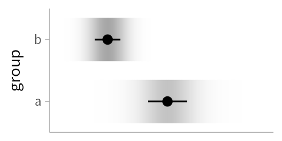

```r
p = two_a |>
  ggplot(aes(xdist = dist_student_t(nu, mu, sigma), y = group)) +
  stat_slab(aes(alpha = !!p_(x)), thickness = 1, side = "both", fill_type = "gradient", scale = 0.7) +
  stat_pointinterval(.width = 0.66, linewidth = 0.5) +
  scale_x_continuous(breaks = NULL, limits = c(-3, 14)) +
  scale_y_discrete(expand = expansion(0.15)) +
  scale_alpha_continuous(range = c(0, 1), guide = "none") +
  labs(x = NULL)

p
```

```r
ggsave("figs/3-slab_gradient_two_groups.pdf", device = cairo_pdf)
```

Correll gradients

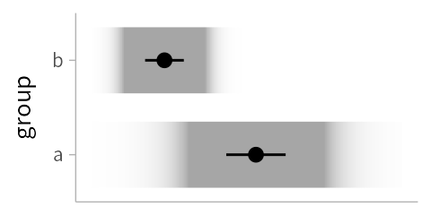

```r
p = two_a |>
  ggplot(aes(xdist = dist_student_t(nu, mu, sigma), y = group)) +
  stat_slab(aes(alpha = - pmax(abs(2*!!Pr_(X <= x) - 1), .95)), thickness = 1, side = "both", fill_type = "gradient", scale = 0.7) +
  stat_pointinterval(.width = 0.66, linewidth = 0.5) +
  scale_x_continuous(breaks = NULL, limits = c(-3, 14)) +
  scale_y_discrete(expand = expansion(0.15)) +
  scale_alpha_continuous(range = c(0, 1), guide = "none") +
  labs(x = NULL)

p
```

```r
ggsave("figs/3-slab_gradient_correll.pdf", device = cairo_pdf)
```

Consonance curve

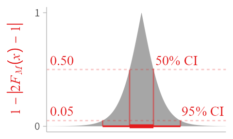

```r
p = two_a |>
  filter(group == "a") |>
  ggplot(aes(xdist = dist_student_t(nu, mu, sigma), y = 0, thickness = 1 - abs(2*!!Pr_(X < x) - 1))) +
  stat_slab(scale = 1) +
  stat_pointinterval(aes(thickness = NULL), .width = c(0.5, .95), side = "top", point_size = 0, color = label_color) +
  geom_hline(yintercept = c(0.05, 0.5), color = label_color, alpha = 0.25, linetype = "22") +
  stat_spike(at = \(x) qi(x, .width = .5), n = 1001, scale = 1, size = 0, color = label_color, alpha = 0.5) +
  stat_spike(at = \(x) qi(x, .width = .95), n = 1001, scale = 1, size = 0, color = label_color, alpha = 0.5) +
  scale_x_continuous(breaks = NULL, limits = c(-3, 14), expand = expansion(0)) +
  scale_y_continuous(expand = expansion(0.05), limits = c(0, 1), breaks = c(0, 1)) +
  label_(x = -2.7, y = c(0.05, 0.5) + .04, label = c("0.05", "0.50"), hjust = 0, vjust = 0) +
  label_(x = c(9.8,7.3), y = c(0.05, 0.5) + .04, label = c("95% CI", "50% CI"), hjust = 0, vjust = 0) +
  scale_thickness_shared() +
  labs(
    x = NULL,
    y = quote(1 - abs(2 * italic(F)[italic(M)](italic(x)) - 1))
  ) +
  theme(axis.title.y.left = element_text(family = "serif", color = label_color))

p
```

```r
ggsave("figs/3-slab_consonance.pdf", device = cairo_pdf)
```

Helske violin gradients

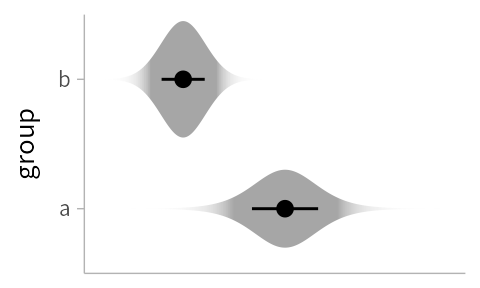

```r
p = two_a |>
  ggplot(aes(xdist = dist_student_t(nu, mu, sigma), y = group)) +
  stat_slab(aes(alpha = - pmax(abs(2*!!Pr_(X <= x) - 1), .85)), side = "both", fill_type = "gradient") +
  stat_pointinterval(.width = 0.66, linewidth = 0.5) +
  scale_x_continuous(breaks = NULL, limits = c(-3, 14)) +
  scale_y_discrete(expand = expansion(0.15)) +
  scale_alpha_continuous(range = c(0, 1), guide = "none") +
  labs(x = NULL)

p
```

```r
ggsave("figs/3-slab_violin_gradient.pdf", device = cairo_pdf)
```

Helske-like violin intervals:

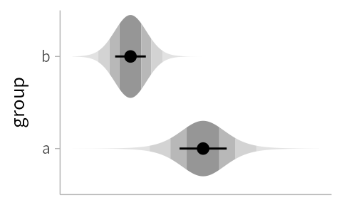

```r
p = two_a |>
  ggplot(aes(xdist = dist_student_t(nu, mu, sigma), y = group)) +
  stat_slab(aes(fill = after_stat(level)), side = "both", .width = c(.5, .8, .95, 1)) +
  stat_pointinterval(.width = 0.66, linewidth = 0.5) +
  scale_x_continuous(breaks = NULL, limits = c(-3, 14)) +
  scale_y_discrete(expand = expansion(0.15)) +
  scale_fill_discrete_sequential(palette = "Light Grays", nmax = 6) +
  guides(fill = "none") +
  labs(x = NULL)

p
```

```r
ggsave("figs/3-slab_violin_interval.pdf", device = cairo_pdf)
```

Raindrop plots:

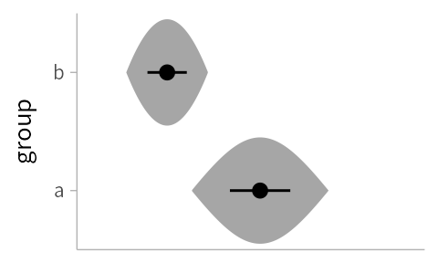

```r
p = two_a |>
  ggplot(aes(xdist = dist_student_t(nu, mu, sigma), y = group)) +
  stat_slab(aes(thickness = ifelse(.width <= .95, log(!!p_(x)), NA)), normalize = "groups", .width = .95, linewidth = 0.5, side = "both") +
  stat_pointinterval(.width = 0.66, linewidth = 0.5) +
  scale_x_continuous(breaks = NULL, limits = c(-3, 14)) +
  scale_y_discrete(expand = expansion(0.15)) +
  guides(alpha = "none") +
  labs(x = NULL)

p
```

```r
ggsave("figs/3-slab_raindrop.pdf", device = cairo_pdf)
```

Fuzzygrams:

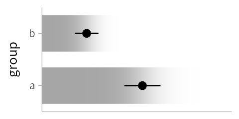

```r
p = two_a |>
  ggplot(aes(xdist = dist_student_t(nu, mu, sigma), y = group)) +
  stat_slab(aes(alpha = !!Pr_(X > x)), thickness = 1, side = "both", fill_type = "gradient", scale = 0.7) +
  stat_pointinterval(.width = 0.66, linewidth = 0.5) +
  scale_x_continuous(breaks = NULL, limits = c(-3, 14), expand = expansion(0)) +
  scale_y_discrete(expand = expansion(0.15)) +
  scale_alpha_continuous(range = c(0, 1), guide = "none") +
  labs(x = NULL)

p
```

```r
ggsave("figs/3-slab_fuzzygram.pdf", device = cairo_pdf)
```

Regions of practical equivalence:

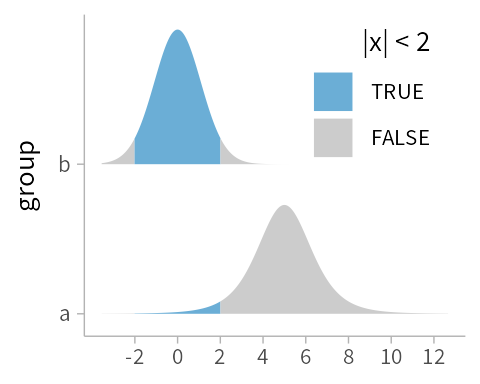

```r
two_a_zero = data.frame(
  nu = c(5, 60),
  mu = c(5, 0),
  sigma = c(1.3, 1.1),
  group = factor(c("a", "b"))
)

p = two_a_zero |>
  ggplot(aes(xdist = dist_student_t(nu, mu, sigma), y = group)) +
  stat_slab(aes(fill = after_stat(abs(x) < 2))) +
  # stat_pointinterval(.width = 0.66, linewidth = 0.5, color = label_color) +
  scale_x_continuous(breaks = seq(-2, 14, by = 2)) +
  scale_y_discrete(expand = expansion(0.15)) +
  scale_fill_manual(
    values = c("FALSE" = "gray80", "TRUE" = blue_),
    guide = guide_legend(reverse = TRUE, title.hjust = 1)
  ) +
  labs(x = NULL, fill = "|x| < 2") +
  theme(legend.position = c(0.75,0.75))

p
```

```r
ggsave("figs/3-slab_rope.pdf", device = cairo_pdf)
```

### Dotplots

Two dotplots:

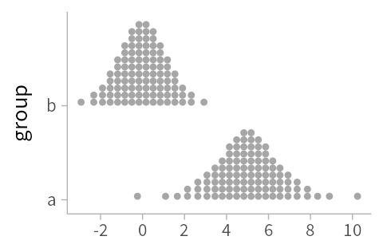

```r
p = two_a_zero |>
  ggplot(aes(xdist = dist_student_t(nu, mu, sigma), y = group)) +
  stat_dots(quantiles = 100) +
  scale_x_continuous(breaks = seq(-2, 14, by = 2)) +
  scale_y_discrete(expand = expansion(0.15)) +
  labs(x = NULL)

p
```

```r
ggsave("figs/3-dots_two.pdf", device = cairo_pdf)
```

Dotplots with emoji:

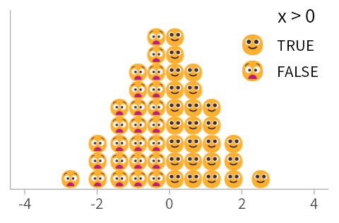

```r
p = two_a_zero |>
  filter(group == "b") |>
  ggplot(aes(xdist = dist_student_t(nu, mu, sigma))) +
  # geom_vline(xintercept = 0, color = "gray85", linewidth = 0.25) +
  stat_dots(aes(shape = after_stat(x > 0)), quantiles = 50, stackratio = 1.1, dotsize = 0.9) +
  scale_x_continuous(breaks = seq(-4, 4, by = 2), limits = c(-4, 4)) +
  scale_y_continuous(breaks = NULL, expand = expansion(0.01)) +
  scale_shape_manual(
    values = c("FALSE" = "😧", "TRUE" = "🙂"),
    guide = guide_legend(reverse = TRUE, title.hjust = 0.92, override.aes = list(linewidth = 3))
  ) +
  labs(x = NULL, y = NULL) +
  theme(
    legend.position = c(0.85,0.8),
    legend.spacing.x = unit(4, 'pt'),
    legend.spacing.y = unit(4, 'pt'),
    legend.key.size = unit(14, "pt")
  )

p
```

```r
ggsave("figs/3-dots_emoji.png", device = agg_png, dpi = 900)
```

## Implementation

Helske-esque interval-density plots used for the implementation figure:

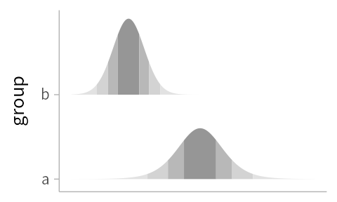

```r
p = two_a |>
  ggplot(aes(xdist = dist_student_t(nu, mu, sigma), y = group)) +
  stat_slab(aes(fill = after_stat(level)), .width = c(.5, .8, .95, 1)) +
  # scale_x_continuous(breaks = seq(0, 14, by = 3), limits = c(-3, 14)) +
  scale_x_continuous(breaks = NULL, limits = c(-3, 14)) +
  scale_y_discrete(expand = expansion(0.15)) +
  scale_fill_discrete_sequential(palette = "Light Grays", nmax = 6) +
  guides(fill = "none") +
  labs(x = NULL)

p
```

```r
ggsave("figs/4-slab.pdf", device = cairo_pdf)
```

## Lessons learned

### Jacobians

Log-normal distribution on the original scale (using `stat_function()`):

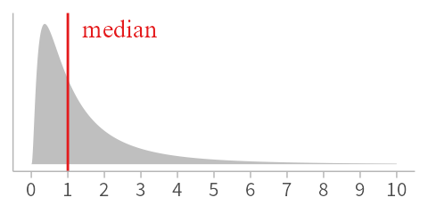

```r
p = ggplot() +
  stat_function(fun = \(x) dlnorm(x, 0, 1), n = 1000, fill = "gray75", geom = "area") +
  geom_vline(xintercept = 1, color = label_color, linewidth = 0.5) +
  label_(x = 1.4, y = 0.675, label = "median", vjust = 1, hjust = 0) +
  scale_x_continuous(limits = c(0, 10), breaks = 0:10) +
  scale_y_continuous(breaks = NULL) +
  labs(x = NULL, y = NULL)

p
```

```r
ggsave("figs/3-jacobian-lognorm.pdf", device = cairo_pdf)
```

Incorrect log-normal distribution on the log scale (using `stat_function()`):

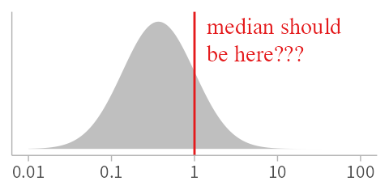

```r
p = ggplot() +
  stat_function(fun = \(x) dlnorm(x, 0, 1), n = 1000, geom = "area", fill = "gray75") +
  geom_vline(xintercept = 1, color = label_color, linewidth = 0.5) +
  label_(x = 1.4, y = 0.675, label = "median should\nbe here???", vjust = 1, hjust = 0) +
  scale_x_log10(limits = 10^c(-2,2), breaks = 10^(-2:2), labels = as.character) +
  scale_y_continuous(breaks = NULL) +
  labs(x = NULL, y = NULL)

p
```

```r
ggsave("figs/3-jacobian-incorrect.pdf", device = cairo_pdf)
```

Correct log-normal distribution on the log scale (using `stat_slab()`):

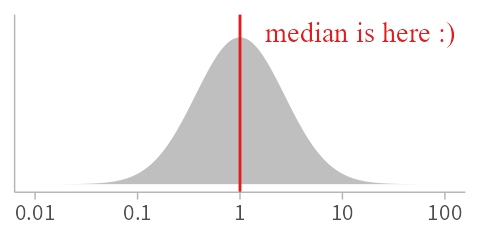

```r
p = ggplot() +
  stat_slab(aes(xdist = dist_lognormal(0, 1)), scale = 1, fill = "gray75") +
  geom_vline(xintercept = 1, color = label_color, linewidth = 0.5) +
  label_(x = 1.75, y = 1.1, label = "median is here :)", vjust = 1) +
  scale_x_log10(limits = 10^c(-2,2), breaks = 10^(-2:2), labels = as.character) +
  scale_y_continuous(breaks = NULL) +
  labs(x = NULL, y = NULL)

p
```

```r
ggsave("figs/3-jacobian-correct.pdf", device = cairo_pdf)
```